# Séance 3 : Analyse de réseaux avec R

Cécile Armand

2025-10-15

# Introduction

## Objectifs

Cette séance à pour objectif d’introduire les principaux concepts de l’analyse formelle de réseau et de se familiariser avec ses méthodes, en particulier :

- les **mesures globales** permettant d’analyser la structure du réseau (e.g., ordre, diamètre, densité) (niveau macro) ;
- les **mesures locales** (centralités) permettant d’analyser la position des noeuds dans le réseau (e.g., degré, intermédiarité) (niveau micro) ;
- la **détection de communautés** permettant d’identifier des sous-groupes de noeuds plus densément connectés à l’intérieur du réseau (au niveau meso) ;
- l’analyse des **liens**, souvent négligées (poids, attributs).

La troisième section introduira la notion **d’équivalence structurale** ou **régulière** qui vise à identifier les entités (acteurs ou autres) qui occupent une position équivalente dans un réseau. Cette méthode est particulièrement intéressante pour analyser les réseaux bipartites.

Ce tutoriel s’appuie principalement sur le package [**igraph**](https://igraph.org/), l’un des plus populaires pour l’analyse et la visualisation de réseau avec R. Pour la recherche d’équivalence, nous utiliserons le package **Places** dédiée spécifiquement à ce type d’analyse.

## Organisation de la séance

Dans cette séance, nous aborderons d’abord les réseaux simples (unimodes) puis les réseaux bipartites. Nous nous appuierons sur deux jeux de données issus des séances précédentes :

1. Pour les **réseaux simples**, nous réutiliserons le **réseau de co-occurrences** extrait du corpus d’articles de presse portant sur Lyon (séance 2).
2. Pour les **réseaux bipartites**, nous reprendrons le jeu de données **auc** consacré aux *alumni* des universités américaines (séance 1)

Ces deux cas très différents illustrent la diversité des applications possibles de l’analyse de réseaux : réseau de mots dans le premier cas, réseau d’acteurs sociaux (individuels ou collectifs) dans le deuxième cas. Ils permettent aussi de couvrir les deux principaux formats sources possibles (matrice dans le premier cas, *edge list* dans le second). Nous verrons aussi comment passer d’un format à l’autre avec *igraph*.

## Préparer ses données : *edge list* ou matrice ?

L’analyse de réseau traite des données relationnelles. Ces données relationnelles peuvent être structurées soit sous forme de **matrices**, soit sous forme de **liste de liens** (*edge list*) (souvent la plus commune).

Le package **igraph** offre différentes fonctions qui permettent de passer d’un format à l’autre :

| Format source | Fonction | Format cible |
| --- | --- | --- |
| matrice d’adjacence | `graph_from_adjacency_matrix()` | graphe |
| graphe | `as_adjacency_matrix()` | matrice |
| edge list (matrice) | `graph_from_edgelist()` | graphe |
| edge list (data.frame) | `graph_from_data_frame()` | graphe |
| graphe | `as_edgelist()` / `as_data_frame()` | edge list |
| graphe | `as_adj_list()` | liste d’adjacence |
| liste d’adjacence | `graph_from_adj_list()` | graphe |

# 1. Réseaux simples

Notre point de départ est la matrice des co-occurrences (les mots qui apparaissent le plus souvent ensemble dans les articles de presse qui portent sur Lyon) construite avec **quanteda** lors de la séance 2. Comme la matrice d’origine est énorme et gourmande en stockage, on l’a reduite pour ne conserver que les co-occurrences concernant les 100 termes les plus fréquents (*fcmat_redux*).

## Convertir une matrice en graphe

```r
g1 <- fcmat_redux %>%
  as.matrix() %>%
  graph_from_adjacency_matrix(mode = "max", weighted = TRUE, diag = FALSE)
```

**Explication ligne à ligne** :

- `g1 <-` : On crée un **objet nommé `g1`** qui contiendra un graphe (graph object). L’opérateur `<-` affecte à `g1` le résultat des opérations effectuées à droite.
- `fcmat_redux` : On part de l’objet nommé `fcmat_redux` (la **matrice de co-occurrences** construite avec **quanteda** dans la séance 2, qui représente les co-occurrences des mots dans le corpus Lyon). Comme on l’a vu dans la première séance, le symbole `%>%` est un **pipe** (fourni par `dplyr` ou `magrittr`) qui permet d’enchaîner les opérations de manière lisible : le résultat de cette ligne sera passé à la ligne suivante comme premier argument.
- `as.matrix()` : On convertit `fcmat` en matrice classique de type `matrix`. Comme une `fcm` de quanteda n’est pas une vraie matrice R, il est nécessaire de la transformer. Cela permet de s’assurer que l’objet est bien au format attendu pour la fonction suivante (`graph_from_adjacency_matrix`).
- `graph_from_adjacency_matrix()` : la fonction **graph_from_adjacency_matrix()** du package **igraph** permet de créer un **graphe** à partir de cette matrice. On définit les paramètres suivants :
- `mode = "undirected"` : le graphe sera **non orienté** (les relations vont dans les deux sens, comme pour des co-occurrences entre mots). Note : dans la version 1.6.O d’igraph, on utilise `mode = "max"` pour forcer la symétrie si la matrice n’est pas parfaitement symétrique (ce qui est le cas ici, ce qui est dû au fait que nous travaillons sur une version réduite de la matrice).
- `weighted = TRUE` : les **poids** de la matrice (le nombre de fois que deux mots co-apparaissent) seront utilisés comme **poids des arêtes (liens)**.
- `diag = FALSE` : on ignore la **diagonale** de la matrice, ce qui revient à éliminer les boucles entre un nœud et lui-même (*self-loops*), autrement, il n’y aura pas de lien d’un mot avec lui-même.

Le résultat final est un objet `g1` de type **igraph**, représentant un graphe non orienté et pondéré construit à partir des co-occurrences dans `fcmat`.

**Bon à savoir** Pour convertir le graphe en dataframe et l’exporter pour le projeter dans un logiciel de type Gephi ou Cytoscape, on peut utiliser la fonction **as_data_frame** fourni par **igraph** et ensuite sauvegarder la liste de liens sous forme de fichier csv:

```r
g1_edgelist <- as_data_frame(g1, what = "edges")

head(g1_edgelist)
```

|  | from | to | weight |
| --- | --- | --- | --- |
| 1 | france | year | 42 |
| 2 | france | rates | 3 |
| 3 | france | london | 809 |
| 4 | france | paris | 3428 |
| 5 | france | lyons | 679 |
| 6 | france | china | 78 |

```r
write.csv(g1_edgelist, "g1_edgelist.csv")
```

## Inspecter

Commençons par inspecter l’objet graphe que l’on vient de créer :

```r
g1
```

```
## IGRAPH 117182a UNW- 100 4347 --
## + attr: name (v/c), color (v/n), group (v/n), weight (e/n)
## + edges from 117182a (vertex names):
##  [1] france--year      france--rates     france--london    france--paris
##  [5] france--lyons     france--china     france--general   france--chairman
##  [9] france--street    france--bank      france--saigon    france--manila
## [13] france--japan     france--singapore france--hong      france--road
## [17] france--yokohama  france--kobe      france--york      france--hongkong
## [21] france--current   france--received  france--shanghai  france--central
## [25] france--limited   france--nagasaki  france--tientsin  france--office
## [29] france--peking    france--national  france--every     france--canton
## + ... omitted several edges
```

Ce qu’on voit ici est une **description succincte** d’un objet `igraph`, affichée automatiquement lorsqu’on tape son nom dans la console (juste `g1` ou `print(g1)` ou encore `summary(g1)`). Décryptons-la ligne à ligne :

- `IGRAPH` : indique que c’est un objet de type `igraph`.
- `117182a` : un identifiant unique de l’objet en mémoire (on peut l’ignorer).
- `UNW-` : un code abrégé qui résume les caractéristiques structurelles du graphe :
  - `U` = **Undirected** → le graphe est **non orienté**
  - `N` = **Named** → les nœuds ont un attribut `name`
  - `W` = **Weighted** → les arêtes ont un attribut `weight`
  - `-` = pas d’autre propriété notable (ex. pas de multiple edges, pas de loops…)
- Le réseau contient 100 noeuds (les 100 mots les plus fréquents) et 4347 liens
- Les attributs associés aux noeuds et aux liens sont les suivants :
  - `name (v/c)` : le nom des noeuds (v = vertice), sous forme d’un vecteur de type caractère (`c` = character).
  - `weight (e/n)` : le poids des liens sous forme d’un vecteur numérique (`n` = numeric).

En résumé, ce graphe `g1` est un graphe non orienté composé de 100 noeuds et 4347 liens. Chaque nœud porte un nom (`name`) et chaque lien a un poids (`weight`).

## Visualiser (1)

Même si voir n’est pas démontrer, il peut être utile de visualiser le graphe afin d’avoir une première intuition de sa structure.

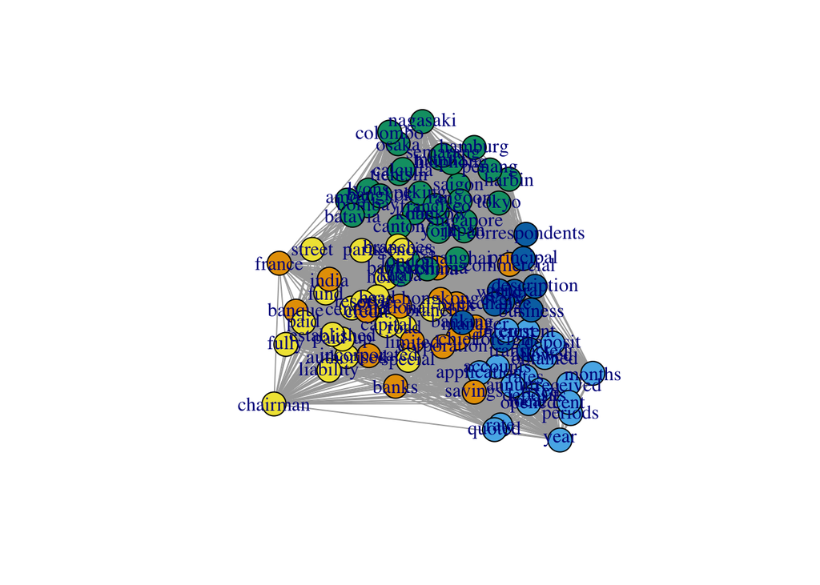

```r
plot(g1)
```

Le résultat n’est pas formidable. On va tenter d’améliorer la lisibilité et l’esthétique du graphe en changeant la couleur des noeuds, la position et la couleur des étiquettes, le layout. Nous allons aussi ajouter un titre :

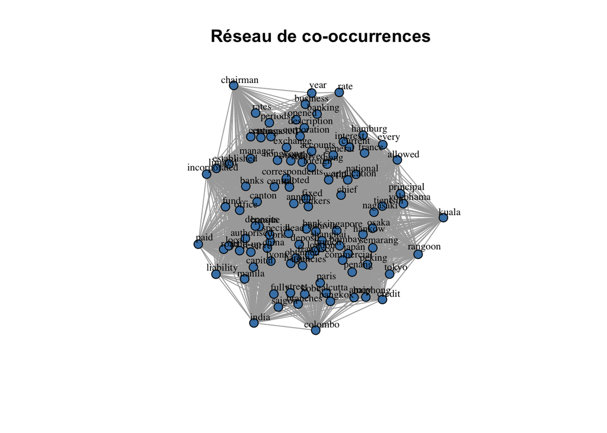

```r
plot(g1, vertex.size = 7,
     vertex.color = "steelblue",
     vertex.label.color = "black",
     vertex.label.cex = 0.7,
     vertex.label.dist = 1,
     layout = layout_with_drl,
     main="Réseau de co-occurrences")
```

**Décryptage**

- g1 : objet igraph représentant le graphe à tracer.
- vertex.size = 7 : taille des nœuds ; ici, taille moyenne pour bonne visibilité.
- vertex.color = “steelblue” : couleur de remplissage des nœuds (bleu acier).
- vertex.label.color = “black” : couleur du texte des étiquettes des nœuds (noir, pour bonne lisibilité).
- vertex.label.cex = 0.7 : taille du texte des étiquettes (70 % de la taille standard).
- vertex.label.dist = 1 : distance entre l’étiquette et le nœud ; éloigne le texte pour éviter le chevauchement.
- layout = layout_with_drl : algorithme de mise en page DRL (Distributed Recursive Layout), efficace pour les grands graphes ou réseaux éclatés.
- main = “Réseau de co-occurrences” : titre du graphe, affiché en haut de la figure.

**Bon à savoir**

1. Pour obtenir la **liste des couleurs** diponibles dans R :

```r
colors()
```

2. Pour obtenir la **liste des layouts** diponibles dans **igraph**:

```r
ls("package:igraph", pattern = "^layout_")
```

Comparons différents layouts sur notre réseau:

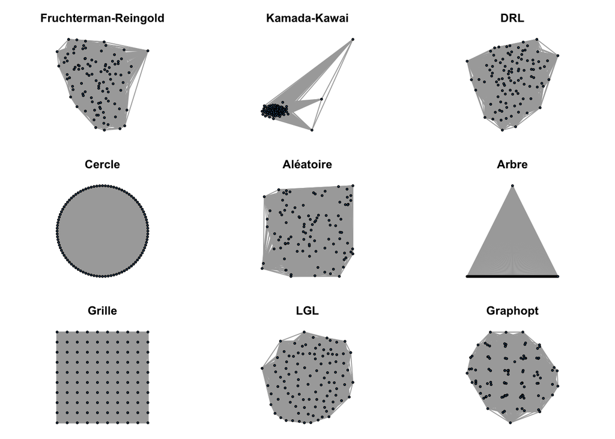

```r
# Préparer une grille 3x3
par(mfrow = c(3, 3), mar = c(1, 1, 3, 1))  # marges réduites

# Layout 1 : Fruchterman-Reingold
plot(g1, layout = layout_with_fr(g1),
     vertex.size = 4, vertex.label = NA,
     vertex.color = "steelblue",
     main = "Fruchterman-Reingold")

# Layout 2 : Kamada-Kawai
plot(g1, layout = layout_with_kk(g1),
     vertex.size = 4, vertex.label = NA,
     vertex.color = "steelblue",
     main = "Kamada-Kawai")

# Layout 3 : DRL (Distributed Recursive Layout)
plot(g1, layout = layout_with_drl(g1),
     vertex.size = 4, vertex.label = NA,
     vertex.color = "steelblue",
     main = "DRL")

# Layout 4 : Cercle
plot(g1, layout = layout_in_circle(g1),
     vertex.size = 4, vertex.label = NA,
     vertex.color = "steelblue",
     main = "Cercle")

# Layout 5 : Aléatoire
plot(g1, layout = layout_randomly(g1),
     vertex.size = 4, vertex.label = NA,
     vertex.color = "steelblue",
     main = "Aléatoire")

# Layout 6 : Arborescent
plot(g1, layout = layout_as_tree(g1),
     vertex.size = 4, vertex.label = NA,
     vertex.color = "steelblue",
     main = "Arbre")

# Layout 7 : Grille
plot(g1, layout = layout_on_grid(g1),
     vertex.size = 4, vertex.label = NA,
     vertex.color = "steelblue",
     main = "Grille")

# Layout 8 : LGL (Large Graph Layout)
plot(g1, layout = layout_with_lgl(g1),
     vertex.size = 4, vertex.label = NA,
     vertex.color = "steelblue",
     main = "LGL")

# Layout 9 : Graphopt
plot(g1, layout = layout_with_graphopt(g1),
     vertex.size = 4, vertex.label = NA,
     vertex.color = "steelblue",
     main = "Graphopt")
```

```r
par(mfrow = c(1, 1)) # supprimer la grille
```

On va maintenant étayer ces intuitions en utilisant différents outils de mesures globales et locales fournis par le package **igraph**.

## Mesures globales

Différentes mesures existent pour décrire la structure d’un graphe dans sa globalité. Nous verrons ici les plus couramment utilisées. Pour une liste détaillée, voir l’aide-mémoire et la documentation du package **igraph**

```r
gorder(g1) # nombre de noeuds (order)
gsize(g1) # nombre de liens (size)
diameter(g1) # diamètre
mean_distance(g1) # distance moyenne entre les noeuds
edge_density(g1) # densité du graphe
transitivity(g1) # transitivité
components(g1) # nombre de composantes connexes
is_connected(g1) # le graphe est-il connexe ?
```

**Note** Ces mesures globales sont souvent utiles pour comparer des réseaux (ici par exemple, les réseaux sémantiques issus de différents corpus ou différentes sources), mais en soi elles sont peu informatives et difficiles à interpreter isolément.

## Mesures locales (centralités)

Les mesures de centralité servent à mesurer la position d’un noeud dans un réseau. De nombreuses mesures de centralité peuvent être calculées avec igraph. Les plus couramment utilisées sont mises en oeuvre dans le code ci-dessous. Pour une liste plus détaillée, voir le tableau ci-dessous :

```r
# Degré
degree(g1)
degree(g1, normalized = TRUE) # degré normalisé : utile pour comparer des graphes de tailles différentes

# Intermédiarité
betweenness(g1)

# Proximité
closeness(g1)

# Eigenvector
eigen_centrality(g1)$vector

# PageRank
page_rank(g1)$vector
```

**Liste détaillée**

| Centralité | Fonction `igraph` | Description |
| --- | --- | --- |
| **Degré** | `degree()` | Nombre d’arêtes connectées à un sommet (entrantes, sortantes ou totales). |
| **Intermédiarité (nœuds)** | `betweenness()` | Compte le nombre de plus courts chemins passant par un sommet. |
| **Intermédiarité (arêtes)** | `edge_betweenness()` | Compte le nombre de plus courts chemins passant par une arête. |
| **Proximité** | `closeness()` | Inverse de la somme des distances d’un sommet aux autres (plus petite = plus central). |
| **Éigenvector (valeur propre)** | `eigen_centrality()` | Tient compte non seulement du nombre de voisins, mais aussi de leur influence. |
| **Centralité de Katz** | `alpha_centrality()` | Variante pondérée de la centralité de degré, intégrant les chemins indirects (et orientés). |
| **Centralité de Bonacich** | `power_centrality()` | Généralisation de la centralité de Katz avec paramètre d’influence. |
| **PageRank** | `page_rank()` | Modélise la probabilité de visite d’un sommet par un “surfeur aléatoire” (comme Google). |
| **Rayonnement (hub/authority)** | `hit_scores()` | Score des hubs (émetteurs forts) et des autorités (récepteurs forts), selon l’algorithme HITS. |
| **Rayonnement total (directed)** | `subgraph_centrality()` | Nombre de sous-graphes auxquels un nœud participe (rarement utilisé car coûteux). |

**Remarques importantes**

1. Pour les graphes orientés, plusieurs fonctions prennent **mode = “in”**, **“out”** ou **“all”**.
2. Certaines mesures sont sensibles aux composantes connexes : si le graphe est non connexe, les mesures de **betweeneness()** et **closeness()** peuvent retourner des valeurs biaisées.
3. Certaines mesures comme **hub/authority** ne s’appliquent que dans les réseaux orientés.

Pour combiner ces différentes mesures dans un seul dataframe et les exporter au format csv, on peut appliquer le code suivant :

```r
# Calcul des différentes centralités

g1_centrality <- data.frame(
  node = V(g1)$name,
  degree = degree(g1),
  degree_norm = degree(g1, normalized = TRUE),
  betweenness = betweenness(g1),
  closeness = closeness(g1),
  eigenvector = eigen_centrality(g1)$vector,
  pagerank = page_rank(g1)$vector)
```

```r
# Afficher un aperçu

g1_centrality %>%
  head(5) %>%
  kable() %>%
  kable_styling(full_width = FALSE, bootstrap_options = c("striped", "hover"))
```

|  | node | degree | degree_norm | betweenness | closeness | eigenvector | pagerank |
| --- | --- | --- | --- | --- | --- | --- | --- |
| france | france | 81 | 0.8181818 | 29.51456 | 0.0033557 | 0.0573763 | 0.0045438 |
| year | year | 93 | 0.9393939 | 15.35477 | 0.0032154 | 0.0569192 | 0.0060596 |
| rates | rates | 89 | 0.8989899 | 26.33849 | 0.0033333 | 0.1607802 | 0.0090095 |
| london | london | 99 | 1.0000000 | 0.00000 | 0.0009083 | 0.5054642 | 0.0229214 |
| paris | paris | 91 | 0.9191919 | 14.63039 | 0.0029674 | 0.1514488 | 0.0090511 |

```r
# Exporter au format CSV

write.csv(g1_centrality, "g1_centrality_measures.csv", row.names = FALSE)
```

## Mesures sur les liens

Les deux principales mesures sont le poids des liens (si le réseau est valué) et leur intérmédiarité.

```r
head(table(E(g1)$weight)) # table des poids
```

```
##
##   1   2   3   4   5   6
## 317 198 123 115  80  77
```

On peut utiliser cette table pour filtrer les liens en fonction de leur poids :

```r
head(E(g1)[weight > 1]) # tous les liens dont le poids est supérieur à 1
```

```
## + 6/4347 edges from 117182a (vertex names):
## [1] france--year   france--rates  france--london france--paris  france--lyons
## [6] france--china
```

```r
E(g1)[weight == 100] # tous les liens qui ont un poids de 100 (connectant tous les noeuds)
```

```
## + 9/4347 edges from 117182a (vertex names):
## [1] amoy       --reserve   shanghai   --india     office     --principal
## [4] peking     --semarang  hankow     --business  interest   --head
## [7] accounts   --reserve   application--principal exchange   --banks
```

L’intermédiarité d’un lien ou arête mesure combien de fois cette arête est empruntée par les plus courts chemins reliant tous les couples de nœuds dans le graphe. Autrement dit, une arête avec une valeur élevée se trouve souvent sur les plus courts chemins → elle connecte des groupes ou des régions du réseau. C’est une arête “stratégique” ou “pont” entre communautés ou clusters (c’est l’équivalent pour les liens de l’intermédiarité des noeuds). La fonction **edge_betweenness()** sert à la calculer :

```r
edge_betweenness(g1) # intermédiarité des liens
```

## Visualiser (2)

On peut intégrer ces informations les noeuds et les liens directement dans la visualisation du graphe. On peut par exemple :

- Indexer la taille des noeuds (et des étiquettes) sur leur centralité
- Indexer l’épaisseur des liens sur leur poids

### Centralités

Par exemple, on visualise l’eigenvector des noeuds :

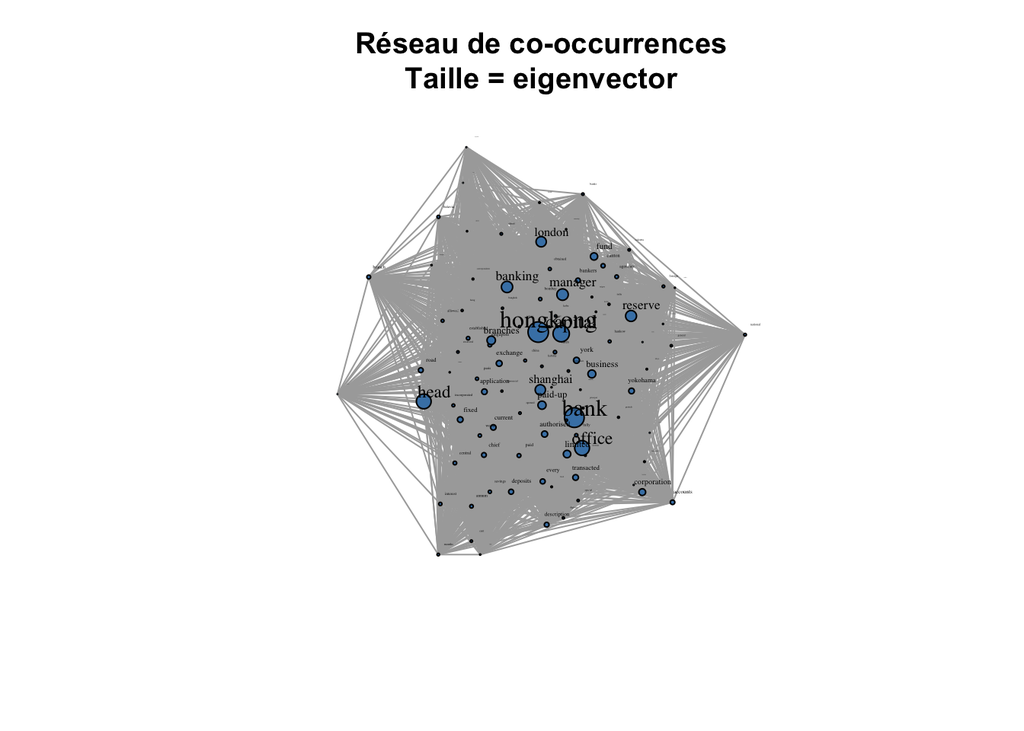

```r
plot(g1, vertex.size = eigen_centrality(g1)$vector*10,
     vertex.color = "steelblue",
     vertex.label.color = "black",
     vertex.label.cex = eigen_centrality(g1)$vector,
     vertex.label.dist = 1,
     layout = layout_with_drl,
     main="Réseau de co-occurrences\nTaille = eigenvector")
```

### Poids des liens

Pour changer **l’apparence des liens** (épaisseur, couleur, inflexion) :

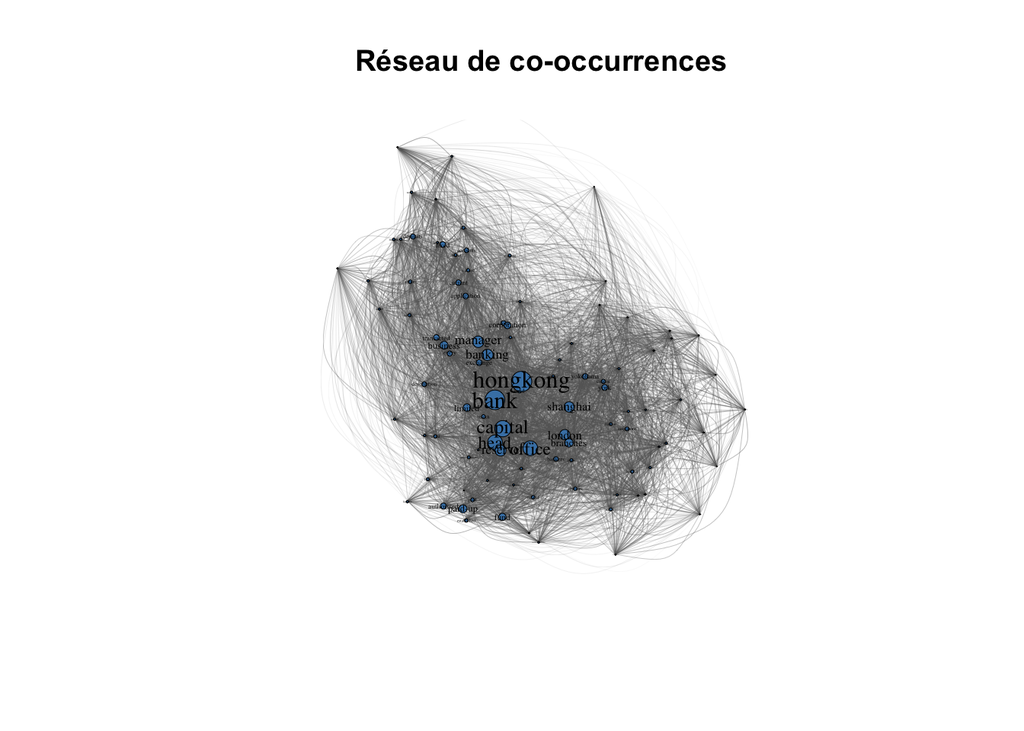

```r
plot(g1,
     vertex.size = eigen_centrality(g1)$vector * 10,
     vertex.color = "steelblue",
     vertex.frame.width = 0.5,           # épaisseur fine des noeuds
     vertex.label.color = "black",
     vertex.label.cex = eigen_centrality(g1)$vector,
     edge.width = log(E(g1)$weight) * 0.025,
     edge.curved = 0.8,
     edge.color = "grey40",
     layout = layout_with_fr,
     main = "Réseau de co-occurrences")
```

## Détection de communautés

La notion de **communauté** (ou *cluster*) en analyse de réseau désigne un sous-ensemble de nœuds plus densément connectés entre eux qu’avec le reste du réseau. La détection de communautés offre une échelle d’analyse intermédiaire (méso), qui se situe entre l’échelle globale du réseau (macro) et celle locale des nœuds individuels ou des dyades (paires de nœuds).

Il existe différentes méthodes pour détecter des communautés, qui renvoient à différentes manières de partitionner le réseau. Aussi le choix de la méthode aura un impact sur la partition finale.

L’avantage d’utiliser R pour la détection de communautés est de pouvoir tester et comparer différents algorithmes et d’en maîtriser pleinement les paramètres.

Nous allons voir dans cette section :

1. Comment choisir et appliquer un algorithme avec **igraph**
2. Comment extraire les membres des communautés, calculer leur taille et leur attribuer un label.
3. Comment visualiser les communautés et les liens intra- et inter-communautés.

### Choix de l’algorithme

La liste des algorithmes de détection de communauté fourni par **igraph** peut être consultée dans la [documentation](https://igraph.org/r/html/1.2.3/communities.html) du package igraph. On peut aussi les lister directement en appliquant ce code :

```r
# Lister tous les algorithmes de détection de communautés disponibles avec igraph

community_algos <- ls("package:igraph", pattern = "^cluster_")
print(community_algos)
```

Comment choisir le bon algorithme ? L’aide-mémoire qui accomapgne ce cours fournit un tableau comparatif et des conseils pour aider à faire son choix.

A titre d’exemple, nous choisissons ici de comparer deux algorithmes : *louvain* et *infomap* :

```r
set.seed(2025) # pour stabiliser les résultats
com_louvain <- cluster_louvain(g1)
com_infomap <- cluster_infomap(g1)
```

**Décryptage** :

La première ligne (set.seed) fixe la graine du générateur aléatoire pour rendre les résultats reproductibles. Certains algorithmes de détection de communautés (comme Infomap ou Label Propagation) incluent des étapes aléatoires (par exemple : initialisation aléatoire, propagation aléatoire, etc.). En fixant une graine (ici 2025, mais on peut choisir un autre nombre tout à fait aléatoire), on s’assure que les résultats obtenus seront les mêmes à chaque exécution du script, ce qui est utile pour comparer des résultats de manière stable, déboguer ou partager du code avec d’autres, écrire des articles ou rapports scientifiques reproductibles.

Les lignes suivantes appliquent successivement les deux algorithmes choisis (cluster_louvain, cluster_infomap) au réseau (g1) et stockent chaque résultats dans une nouvelle variable (com_louvain, com_infomap).

### Inspecter les résultats

```r
print(com_louvain)
```

```
## IGRAPH clustering multi level, groups: 5, mod: 0.4
## + groups:
##   $`1`
##    [1] "france"       "china"        "bank"         "hongkong"
##    [5] "limited"      "national"     "banque"       "manager"
##    [9] "chief"        "commercial"   "banks"        "india"
##   [13] "incorporated" "corporation"  "credit"       "savings"
##
##   $`2`
##    [1] "year"        "rates"       "current"     "received"    "months"
##    [6] "interest"    "accounts"    "fixed"       "deposits"    "local"
##   [11] "application" "allowed"     "periods"     "rate"        "obtained"
##   + ... omitted several groups/vertices
```

```r
print(com_infomap)
```

```
## IGRAPH clustering infomap, groups: 3, mod: 0.31
## + groups:
##   $`1`
##    [1] "france"         "london"         "paris"          "lyons"
##    [5] "china"          "chairman"       "street"         "bank"
##    [9] "saigon"         "manila"         "japan"          "singapore"
##   [13] "hong"           "road"           "yokohama"       "kobe"
##   [17] "york"           "hongkong"       "amoy"           "shanghai"
##   [21] "central"        "limited"        "nagasaki"       "tientsin"
##   [25] "office"         "peking"         "national"       "canton"
##   [29] "special"        "banque"         "capital"        "paid"
##   [33] "manager"        "branches"       "haiphong"       "hankow"
##   + ... omitted several groups/vertices
```

La fonction **print()** (on peut aussi simplement entrer *com_louvain* et *com_infomap* dans la console) indique le nombre de communautés détectées dans chaque cas, leur taille et le score de modularité, qui mesure le degré de partitionnement. La modularité quantifie à quel point les nœuds d’une même communauté sont plus densément connectés entre eux qu’avec le reste du réseau.

| Valeur de `mod.` | Interprétation générale |
| --- | --- |
| ≈ 0 | Pas de structure communautaire détectée |
| 0.3 – 0.5 | Structure communautaire modérée |
| > 0.5 | Structure communautaire forte |
| > 0.7 | Rare ; très forte modularité (souvent artificielle) |

**À noter** Bien que le score de modularité soit souvent utilisé pour mesurer la qualité des résultats, une modularité élevée n’est pas toujours un gage de qualité (effet de résolution, surpartition). Il est important de la combiner avec d’autres analyses visuelles ou structurales.

```r
# taille des communautés

table(sizes(com_louvain))
```

```
##
## 11 16 20 21 32
##  1  1  1  1  1
```

```r
table(sizes(com_infomap))
```

```
##
## 10 21 69
##  1  1  1
```

### Extraire les communautés

Nous allons maintenant extraire les communautés sous forme de dataframe. Cela permet de mieux les examiner et les caractériser :

```r
# Louvain

df_louvain <- data.frame(node = V(g1)$name,
                         membership = membership(com_louvain),
                         method = "Louvain") %>%
  group_by(membership) %>% add_tally(name = "size") # on ajoute la taille de chaque communauté

# Infomap

df_infomap <- data.frame(node = V(g1)$name,
                         membership = membership(com_infomap),
                         method = "Infomap") %>%
  group_by(membership) %>% add_tally(name = "size") # # on ajoute la taille de chaque communauté
```

```r
head(df_louvain)
```

[output not shown]

```r
head(df_infomap)
```

[output not shown]

### Visualiser

Nous allons maintenant visualiser les communautés au sein du réseau en leur appliquant une coleur différente :

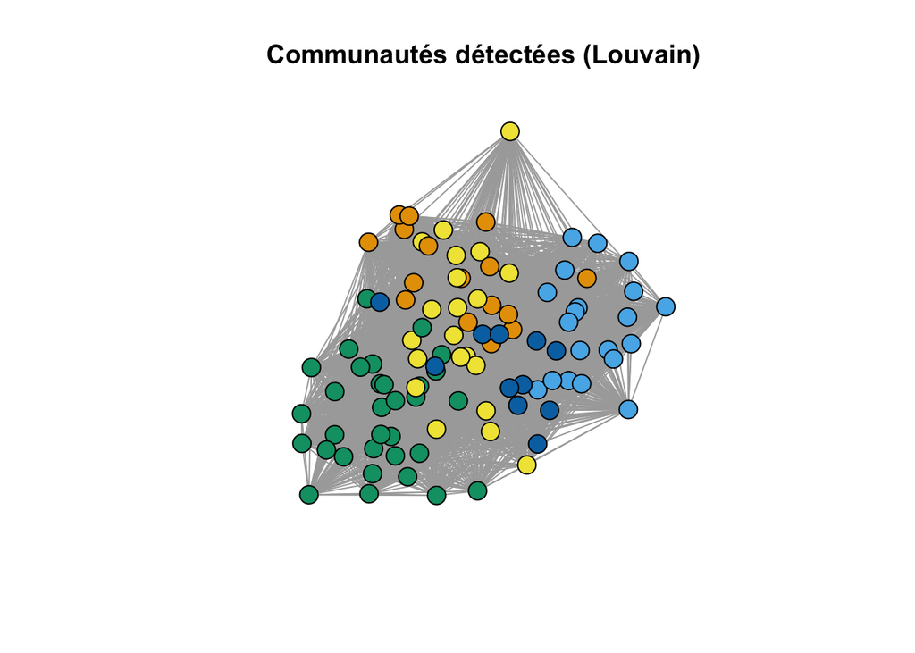

```r
V(g1)$color <- com_louvain$membership

plot(g1,
     vertex.label = NA,
     vertex.size = 10,
     main = "Communautés détectées (Louvain)",
     layout = layout_with_fr(g1))
```

On peut visualiser liens intra- et inter-communautés en attribuant à chaque noeud un groupe qui correspond au numéro de la communauté à laquelle il appartient :

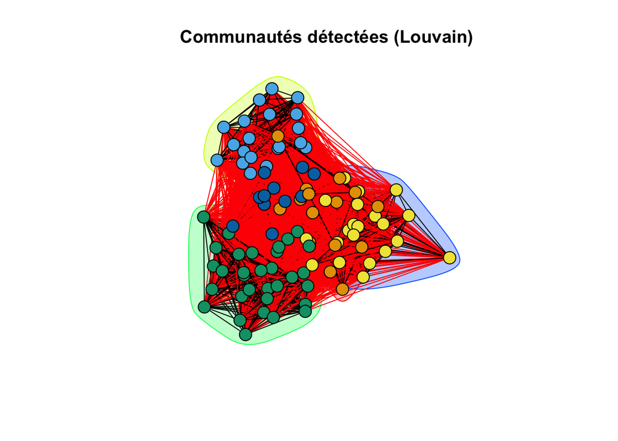

```r
V(g1)$group <- com_louvain$membership

plot(com_louvain, g1,
     vertex.label=NA,
     vertex.size=10,
     main="Communautés détectées (Louvain)")
```

Les liens intra-communuautaires sont représentés en noir, les liens entre communautés figurent en rouge.

### Sous-graphes

Comme le graphe global est difficilement lisible, il peut être utile d’extraire les communautés sous forme de graphes individuels pour mieux les observer. Par exemple ici on extrait les communautés 1 et 5 détectées avec Louvain (on pourrait extraire les autres de la même manière) :

```r
louvain1 <- induced_subgraph(g1, V(g1)$group==1)
louvain5 <- induced_subgraph(g1, V(g1)$group==5)
```

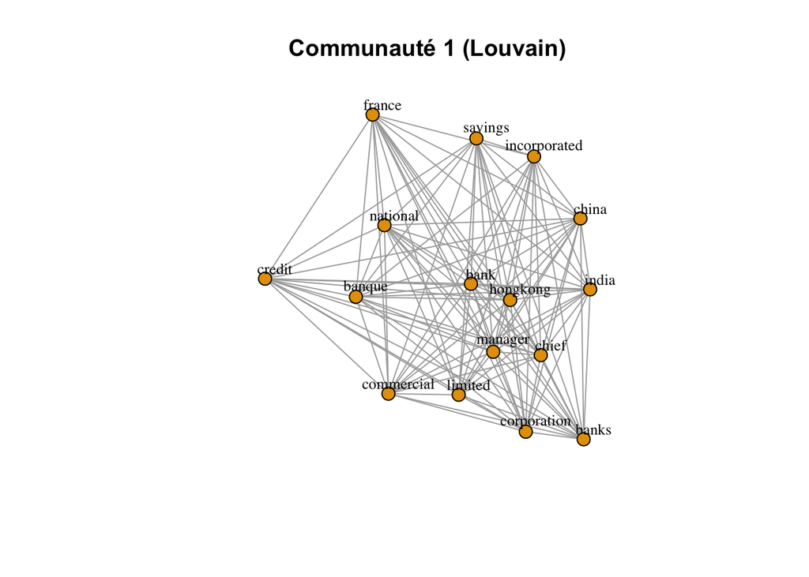

```r
plot(louvain1, vertex.label=V(g1)$id,
     vertex.label.color = "black",
     vertex.label.cex = 0.8,
     vertex.size= 8,
     vertex.label.dist = 1.2,
     main="Communauté 1 (Louvain)")
```

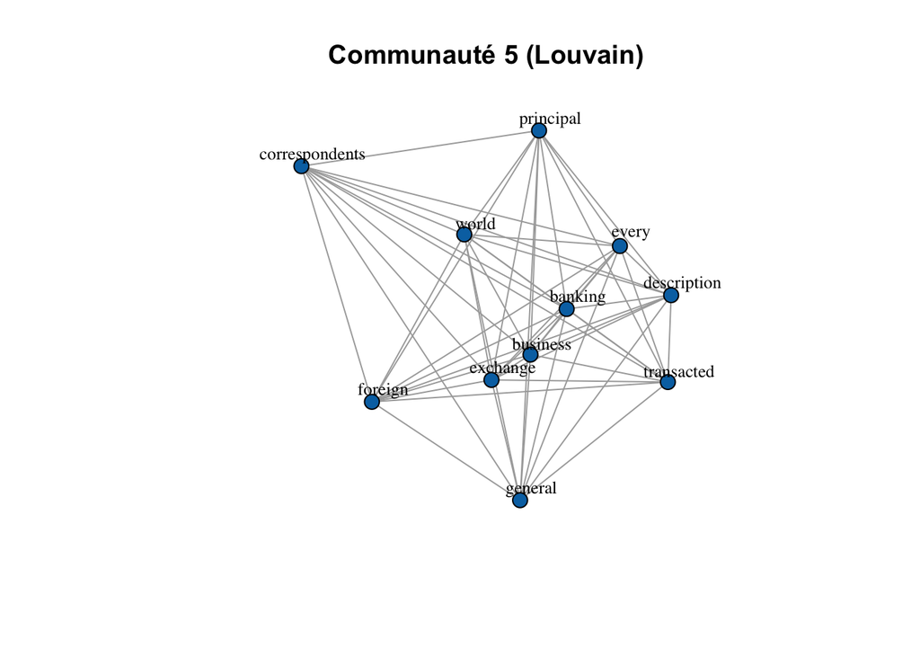

```r
plot(louvain5, vertex.label=V(g1)$id,
     vertex.label.color = "black",
     vertex.label.cex = 0.8,
     vertex.size= 8,
     vertex.label.dist = 1.2,
     main="Communauté 5 (Louvain)")
```

### A vous !

1. Visualisez les communautés détectées avec Infomap.
2. Testez d’autres algorithmes.
3. Comparez et interprétez les résultats obtenus.

# 2. Réseaux bipartites

A la différence du réseau précédent, pour lequel nous sommes partis d’une matrice, le réseau des étudiants est founie sous la forme d’une liste de liens (*edge list*) de type *dataframe*. Plus précisément, les liens d’affiliations entre les alumni et les universités où ils ont étudié.

Dans le cas d’un réseau bipartite, on fournit aussi une liste de noeuds (*node list*), également sous forme de *dataframe*, pour différencier les deux types d’entités présentes dans le réseau (étudiants et université).

**Bon à savoir** En plus de la liste de liens et de noeuds, on peut éventuellement fournir une liste d’attributs apportant des informations complémentaires sur les noeuds, par exemple la nationalité des étudiants ou la localisation des universités. Ces informations peuvent être utiles pour filtrer le réseau ou interpréter les résultats de l’analyse de réseau, mais ne sont pas requis pour sa construction. Le seul élément indispensable à la construction du réseau est la liste de liens. Sans liens, pas de réseau !

## Créer la liste de liens et de noeuds

```r
# charger le jeu de données

library(readr)
auc <- read_delim("Data/auc.csv", delim = ";",
                  escape_double = FALSE, trim_ws = TRUE)

# créer la liste de liens

auc_edge <- auc %>% transmute(Student = Name_full, University)

# créer la liste de noeuds

student_node <- auc_edge %>% distinct(Student) %>% rename(Name = Student) %>% mutate(Type = "Student")
univ_node <- auc_edge %>% distinct(University) %>% rename(Name = University) %>% mutate(Type = "University")
auc_node <- bind_rows(student_node, univ_node)
```

**Note** Si l’on veut intégrer les attributs des liens, par exemple la date ou la nature du diplôme, pour pouvoir filtrer et créer des sous-réseaux par période ou niveau de diplôme, on peut sélectionner les attributs désirés au moment où l’on crée la liste de liens :

```r
auc_edge_att <- auc %>% transmute(Student = Name_full, University,
                                  Degree = Degree_level, Field = Field_main,
                                  Year = Year_start)
```

De même, si l’on souhaite ajouter des attributs aux noeuds, on peut les stocker dans un dataframe à part :

```r
# créer une liste d'attributs sur les noeuds (facultatif)

student_att <- auc %>% transmute(Name = Name_full, Nationality) %>% unique()
```

## Convertir une liste de liens en graphe

On utilise la fonction **graph_from_data_frame()** pour transformer notre liste de liens en graphe. On utilise l’argument **vertices =** pour spécifier la liste de noeuds :

```r
g2 <- graph_from_data_frame(auc_edge, vertices = auc_node, directed = FALSE)
```

Pour indiquer à **igraph** qu’il s’agit d’un réseau bipartite avec deux types de noeuds (des étudiants et des universités), on crée une variable logique (TRUE pour Student, FALSE pour University)

```r
V(g2)$type <- V(g2)$Type == "Student"
```

On vérifie que le graphe est bipartite :

```r
is_bipartite(g2)  # Doit renvoyer TRUE
```

```
## [1] TRUE
```

Inspectons le réseau final

```r
g2
```

```
## IGRAPH 587b013 UN-B 565 682 --
## + attr: name (v/c), Type (v/c), type (v/l), color (v/c), shape (v/c),
## | Nationality (v/c)
## + edges from 587b013 (vertex names):
##  [1] Ting_H.N.   --Pennsylvania    Inui_Kiyosue--Michigan
##  [3] Inui_Kiyosue--Tokyo Imperial  Yu_Leo W.   --Purdue
##  [5] Yu_Leo W.   --Nebraska        Yu_Leo W.   --Nevada
##  [7] Iseri_K.T.  --Stanford        Iseri_K.T.  --Stanford
##  [9] Woo_Herbert --Columbia        Wu_Pond S.  --Purdue
## [11] Wu_Pond S.  --Wisconsin       Wu_Pond S.  --Wisconsin
## [13] Wu_Jack Foy --Stanford        Wu_Jack Foy --Stanford
## + ... omitted several edges
```

## Visualiser un réseau bipartite

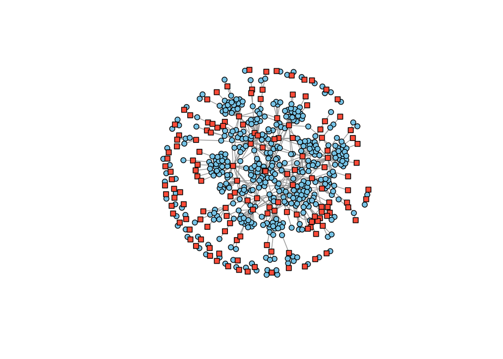

```r
# Définir les couleurs : par exemple, bleu pour les étudiants, rouge pour les universités

V(g2)$color <- ifelse(V(g2)$type, "skyblue", "tomato")

# Définir les formes : cercle pour étudiants, carré pour universités

V(g2)$shape <- ifelse(V(g2)$type, "circle", "square")


# Tracer le graphe en comparant deux layouts différents

plot(g2, vertex.size = 5, vertex.label = NA, layout = layout_with_fr)
```

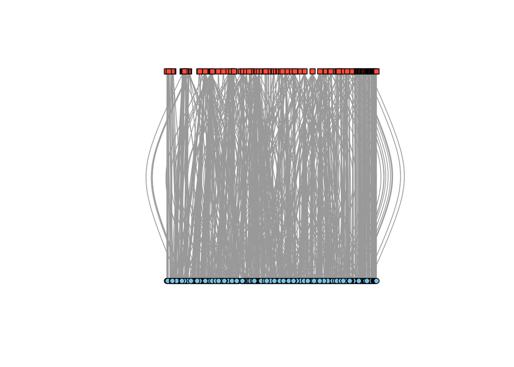

```r
plot(g2, vertex.size = 5, vertex.label = NA, layout = layout_as_bipartite)
```

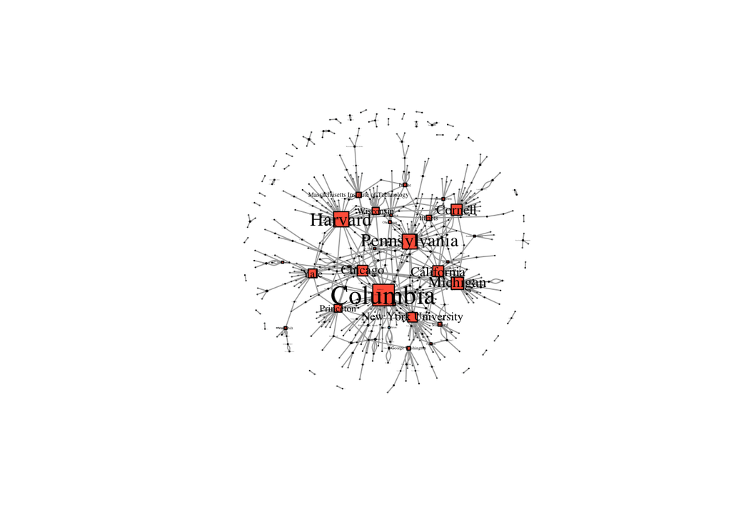

```r
# ajuster la taille des noeuds et des étiquettes pour les rendre proportionnelles au degré de centralité

plot(g2, vertex.size = degree(g2)*0.25,
     vertex.label.cex = degree(g2)*0.025,
     vertex.label.color = "black",
     layout = layout_with_fr)
```